# 2.2 Tree Methods Project

## Tree Methods Project

For this project we will be exploring the use of tree methods to classify schools as Private or Public based off their features.

Let’s start by getting the data which is included in the ISLR library, the College data frame.

## Get the Data

Call the ISLR library and check the head of College (a built-in data frame with ISLR, use data() to check this.) Then reassign College to a dataframe called df

```r
library(ISLR)
df <- College
```

## EDA

Let’s explore the data!

Create a scatterplot of Grad.Rate versus Room.Board, colored by the Private column.

```r
library(ggplot2)
```

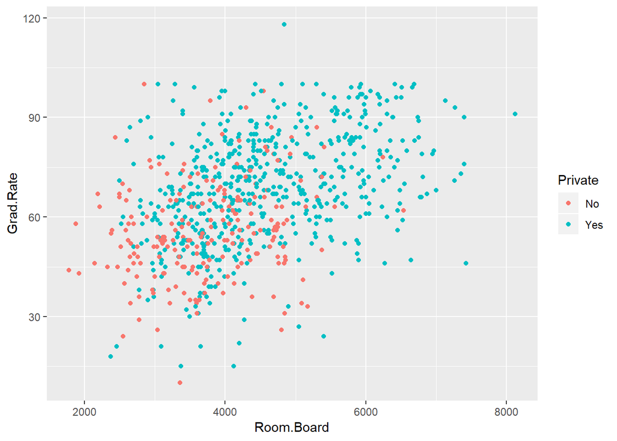

```r
ggplot(df,aes(Room.Board,Grad.Rate)) + geom_point(aes(color=Private))
```

Create a histogram of full time undergrad students, color by Private.

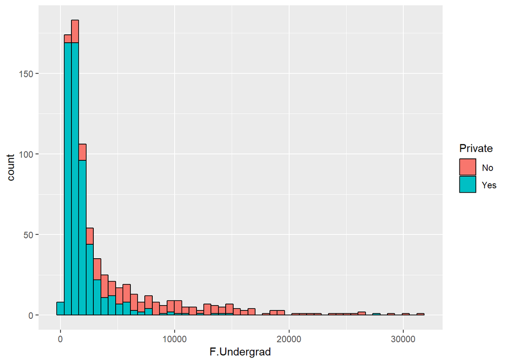

```r
ggplot(df,aes(F.Undergrad)) + geom_histogram(aes(fill=Private),color='black',bins=50)
```

Create a histogram of Grad.Rate colored by Private. You should see something odd here.

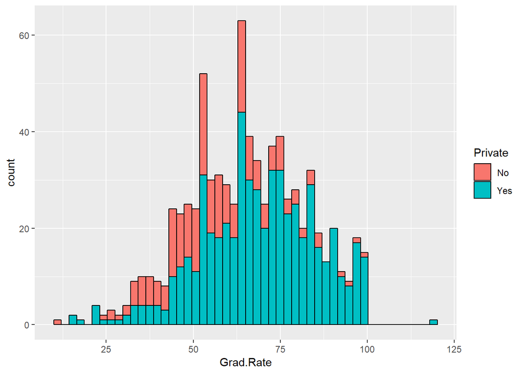

```r
ggplot(df,aes(Grad.Rate)) + geom_histogram(aes(fill=Private),color='black',bins=50)
```

What college had a Graduation Rate of above 100% ?

```r
subset(df,Grad.Rate >100)
```

```
##                   Private Apps Accept Enroll Top10perc Top25perc
## Cazenovia College     Yes 3847   3433    527         9        35
##                   F.Undergrad P.Undergrad Outstate Room.Board Books
## Cazenovia College        1010          12     9384       4840   600
##                   Personal PhD Terminal S.F.Ratio perc.alumni Expend
## Cazenovia College      500  22       47      14.3          20   7697
##                   Grad.Rate
## Cazenovia College       118
```

Change that college’s grad rate to 100%

```r
df['Cazenovia College','Grad.Rate'] <- 100
```

## Train Test Split

Split your data into training and testing sets 70/30. Use the caTools library to do this.

```r
library(caTools)

set.seed(101)

sample = sample.split(df$Private, SplitRatio = .70)
train = subset(df, sample == TRUE)
test = subset(df, sample == FALSE)
```

## Decision Tree

Use the rpart library to build a decision tree to predict whether or not a school is Private. Remember to only build your tree off the training data.

```r
library(rpart)
tree <- rpart(Private ~.,method='class',data = train)
```

Use predict() to predict the Private label on the test data.

```r
tree.preds <- predict(tree,test)
```

Check the Head of the predicted values. You should notice that you actually have two columns with the probabilities.

```r
head(tree.preds)
```

```
##                                                  No       Yes
## Adrian College                          0.003311258 0.9966887
## Alfred University                       0.003311258 0.9966887
## Allegheny College                       0.003311258 0.9966887
## Allentown Coll. of St. Francis de Sales 0.003311258 0.9966887
## Alma College                            0.003311258 0.9966887
## Amherst College                         0.003311258 0.9966887
```

Turn these two columns into one column to match the original Yes/No Label for a Private column.

```r
tree.preds <- as.data.frame(tree.preds)

joiner <- function(x){
    if (x>=0.5){
        return('Yes')
    }else{
        return("No")
    }
}
```

```r
tree.preds$Private <- sapply(tree.preds$Yes,joiner)
```

```r
head(tree.preds)
```

```
##                                                  No       Yes Private
## Adrian College                          0.003311258 0.9966887     Yes
## Alfred University                       0.003311258 0.9966887     Yes
## Allegheny College                       0.003311258 0.9966887     Yes
## Allentown Coll. of St. Francis de Sales 0.003311258 0.9966887     Yes
## Alma College                            0.003311258 0.9966887     Yes
## Amherst College                         0.003311258 0.9966887     Yes
```

```r
table(tree.preds$Private,test$Private)
```

```
##
##        No Yes
##   No   57   9
##   Yes   7 160
```

Use the rpart.plot library and the prp() function to plot out your tree model.

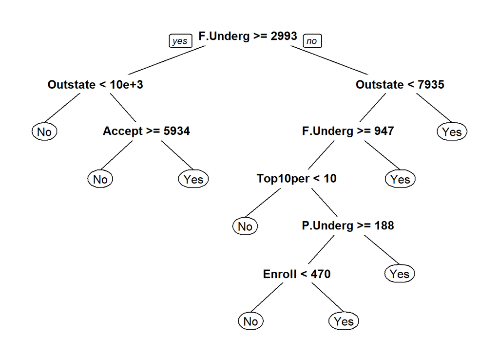

```r
library(rpart.plot)
prp(tree)
```

## Random Forest

Now let’s build out a random forest model!

Call the randomForest package library

```r
library(randomForest)
```

Now use randomForest() to build out a model to predict Private class. Add importance=TRUE as a parameter in the model. (Use help(randomForest) to find out what this does.

```r
rf.model <- randomForest(Private ~ . , data = train,importance = TRUE)
```

What was your model’s confusion matrix on its own training set? Use model$confusion.

```r
rf.model$confusion
```

```
##      No Yes class.error
## No  128  20  0.13513514
## Yes  11 385  0.02777778
```

```r
rf.model$importance
```

```
##                       No          Yes MeanDecreaseAccuracy
## Apps        0.0264825723 1.337054e-02         0.0167996115
## Accept      0.0266512523 1.350260e-02         0.0170035344
## Enroll      0.0321939269 2.745828e-02         0.0287445317
## Top10perc   0.0092354552 4.178847e-03         0.0055778027
## Top25perc   0.0072526625 3.441528e-03         0.0044470666
## F.Undergrad 0.1482062370 7.223168e-02         0.0927247390
## P.Undergrad 0.0375883049 5.652122e-03         0.0143648091
## Outstate    0.1463307045 6.605948e-02         0.0874811571
## Room.Board  0.0186034224 1.360015e-02         0.0150377245
## Books       0.0005445485 2.386036e-05         0.0001481889
## Personal    0.0035610824 1.157282e-03         0.0018302362
## PhD         0.0099422655 5.495726e-03         0.0066942156
## Terminal    0.0039372541 5.337745e-03         0.0049689898
## S.F.Ratio   0.0294975573 8.547645e-03         0.0142013969
## perc.alumni 0.0232705720 3.067149e-03         0.0086415374
## Expend      0.0233150923 1.172527e-02         0.0148611854
## Grad.Rate   0.0183429022 4.794571e-03         0.0085484363
##             MeanDecreaseGini
## Apps                9.827595
## Accept             11.883250
## Enroll             20.307245
## Top10perc           5.525514
## Top25perc           4.352324
## F.Undergrad        42.406669
## P.Undergrad        14.677097
## Outstate           43.328004
## Room.Board         11.560456
## Books               2.355311
## Personal            3.582587
## PhD                 4.442297
## Terminal            4.481134
## S.F.Ratio          14.412133
## perc.alumni         4.904383
## Expend             10.044783
## Grad.Rate           6.843718
```

## Predictions

Now use your random forest model to predict on your test set!

```r
pf.preds <- predict(rf.model,test)
```

```r
table(pf.preds, test$Private)
```

```
##
## pf.preds  No Yes
##      No   56   5
##      Yes   8 164
```

It should have performed better than just a single tree, how much better depends on whether you are emasuring recall, precision, or accuracy as the most important measure of the model.

Great Job!